# Questionnaire Report for Atlantic cod

(MERA version 4.1.6)

robertolicandeo@gmail.com

2019-07-31

# 1 About this document

This is a prototype of an automatic report that documents how the user specified the operating model and their various justifications.

# 2 Introduction

1. Describe the history and current status of the fishery, including fleets, sectors, vessel types and practices/gear by vessel type, landing ports, economics/markets, whether targeted/bycatch, other stocks caught in the fishery.

Atlantic cod is a bottom dwelling North Atlantic fish that ranges from Georges Bank (5Zjm) to Northern Labrador in the Canadian Atlantic. Eastern Georges Bank (eGB) Atlantic cod are a transboundary resource managed collaboratively with the United States (US), and the management unit is Northwest Atlantic Fisheries Organization (NAFO) Division 5Zjm. Tagging studies have shown some mixing between cod in 5Zjm and spawning components in adjacent management units (i.e. 4X5Y), but current management agreements between Canada and the US assume no significant exchange with adjacent stocks (DFO 2011). Historically, the 5Z Atlantic cod stock supported a significant directed fishery. Currently, as a result of substantial declines in stock biomass and consequent low quota levels, only a very small amount of directed fishing takes place, mainly conducted by the fixed gear fleet using longlines, gillnets and handlines. The majority of Atlantic cod in Divisions 5Z are caught as bycatch in a mixed species fishery that includes haddock, halibut, pollock, redfish and other species (4VWX5 Groundfish IFMP). In recent years, Eastern Georges Bank cod quotas have been set at low levels to promote rebuilding, while the Eastern Georges Bank haddock quota has increased since 2013 due to stock increases. As a result, cod quota availability for bycatch needs has been a potentially limiting factor in the haddock fishery in recent years. Under the Canada – US Transboundary Resources Understanding (2003) for groundfish stocks, both countries are responsible for accounting for all fishing mortality under the respective country quotas for yellowtail flounder, cod and haddock. Canada accounts for 3 sources of fishing mortality on 5Zjm: landings and estimated illegal discards from the directed groundfish fleet and estimated legal discards from the offshore Scallop fleet which catches these stocks as an incidental catch.

2. Describe the stock’s ecosystem functions, dependencies, and habitat types.
3. Provide all relevant reference materials, such as assessments, research, and other analysis. Andrushchenko, I., C.M. Legault, R. Martin, E.N. Brooks and Y. Wang. 2018. Assessment of Eastern Georges Bank Cod for 2018. TRAC Reference Document 2018/01

# 3 Fishery Characteristics

## 3.1 Longevity

| Answered |
| --- |
| Very short-lived (5 < maximum age < 7) |
| Short-lived (7 < maximum age < 10) |
| Moderate life span (10 < maximum age < 20) |
| Moderately long-lived (20 < maximum age < 40) |
| Long-lived (40 < maximum age < 80) |
| Very long-lived (80 < maximum age < 160) |

[output not shown]

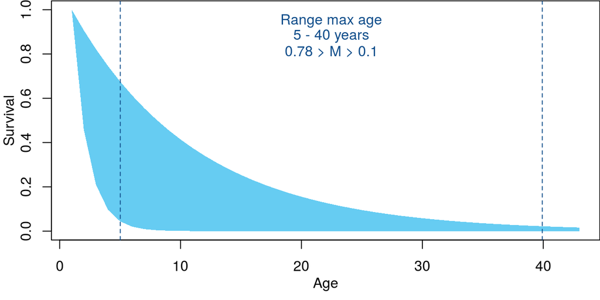

## 3.2 Stock depletion

| Answered |
| --- |
| Crashed (D < 0.05) |
| Very depleted (0.05 < D < 0.1) |
| Depleted (0.1 < D < 0.15) |
| Moderately depleted (0.15 < D < 0.3) |
| Healthy (0.3 < D < 0.5) |
| Underexploited (0.5 < D) |

[output not shown]

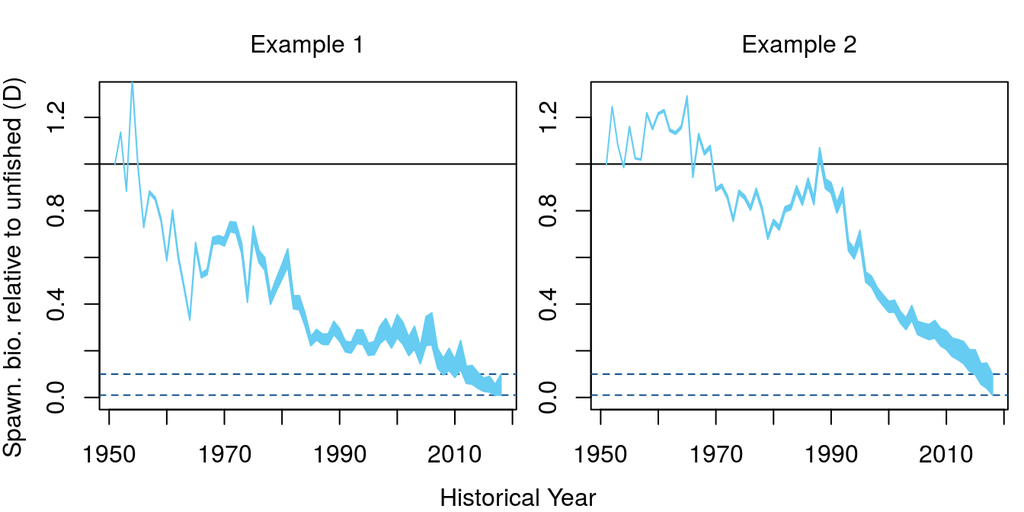

## 3.3 Resilence

| Answered |
| --- |
| Not resilient (steepness < 0.3) |
| Low resilience (0.3 < steepness < 0.5) |
| Moderate resilence (0.5 < steepness < 0.7) |
| Resilient (0.7 < steepness < 0.9) |
| Very Resilient (0.9 < steepness) |

| Justification |
| --- |
| No justification was provided but 0.7 according to Rose and Walters (2019, p5) |

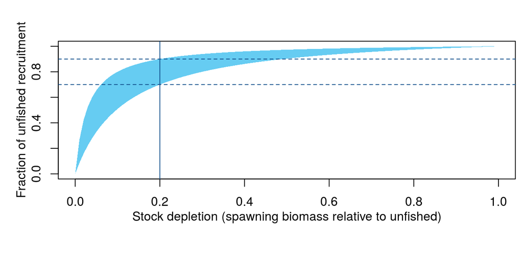

## 3.4 Historical effort pattern

| Answered |
| --- |
| Stable |
| Two-phase |
| Boom-bust |
| Gradual increases |
| Stable, recent increases |
| Stable, recent declines |

| Justification |
| --- |
| see Figure 2 (http://www.dfo-mpo.gc.ca/fisheries-peches/ifmp-gmp/cod-morue/cod-morue-2019-eng.html) |

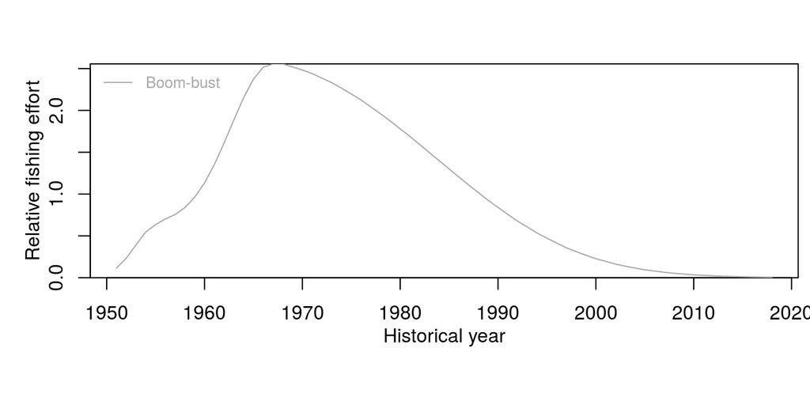

## 3.5 Inter-annual variability in historical effort

| Answered |
| --- |
| Not variable (less than 20% inter-annual change (IAC)) |
| Variable (maximum IAC between 20% to 50%) |
| Highly variable (maximum IAC between 50% and 100%) |

| Justification |
| --- |
| No formation was found. Assessment uses a VPA |

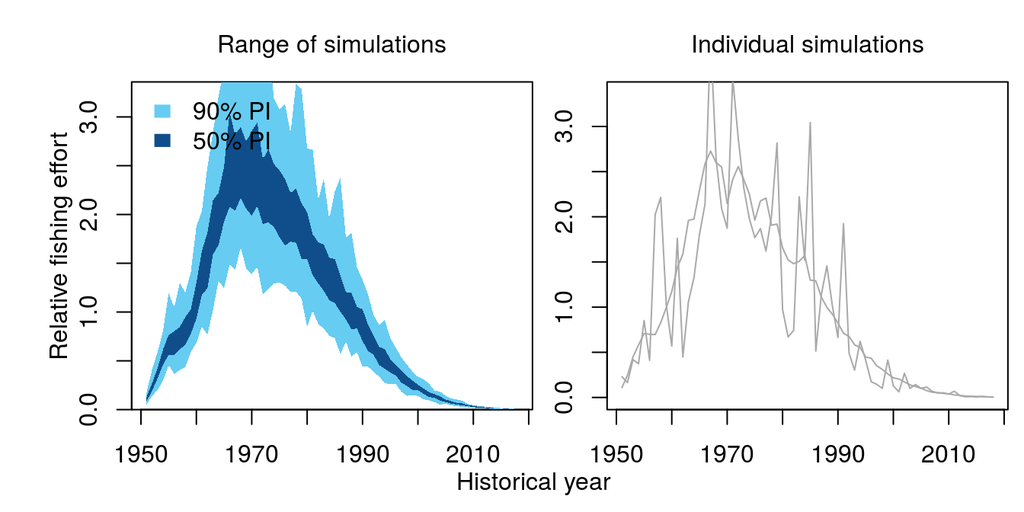

## 3.6 Historical fishing efficiency changes

| Answered |
| --- |
| Declining by 2-3% pa (halves every 25-35 years) |
| Declining by 1-2% pa (halves every 35-70 years) |
| Stable -1% to 1% pa (may halve/double every 70 years) |
| Increasing by 1-2% pa (doubles every 35-70 years) |
| Increasing by 2-3% pa (doubles every 25-35 years) |

| Justification |
| --- |
| No information was provided. Also, model only uses surveys (VPA) |

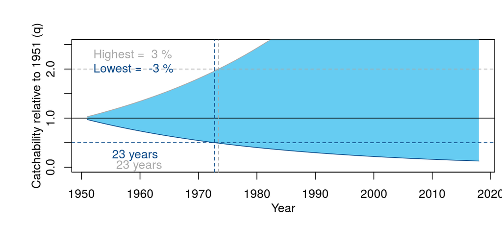

## 3.7 Future fishing efficiency changes

| Answered |
| --- |
| Declining by 2-3% pa (halves every 25-35 years) |
| Declining by 1-2% pa (halves every 35-70 years) |
| Stable -1% to 1% pa (may halve/double every 70 years) |
| Increasing by 1-2% pa (doubles every 35-70 years) |
| Increasing by 2-3% pa (doubles every 25-35 years) |

| Justification |
| --- |
| No information was provided |

[figure not shown]

## 3.8 Length at maturity

| Answered |
| --- |
| Very small (0.4 < LM < 0.5) |
| Small (0.5 < LM < 0.6) |
| Moderate (0.6 < LM < 0.7) |
| Moderate to large (0.7 < LM < 0.8) |
| Large (0.8 < LM < 0.9) |

| Justification |
| --- |
| mean 43.1cm /mean Linf 131.2 (Hunt 1996) for many studies. Age at first reproduction for the 5Zjm stock generally occurs at 2 to 3 years of age. |

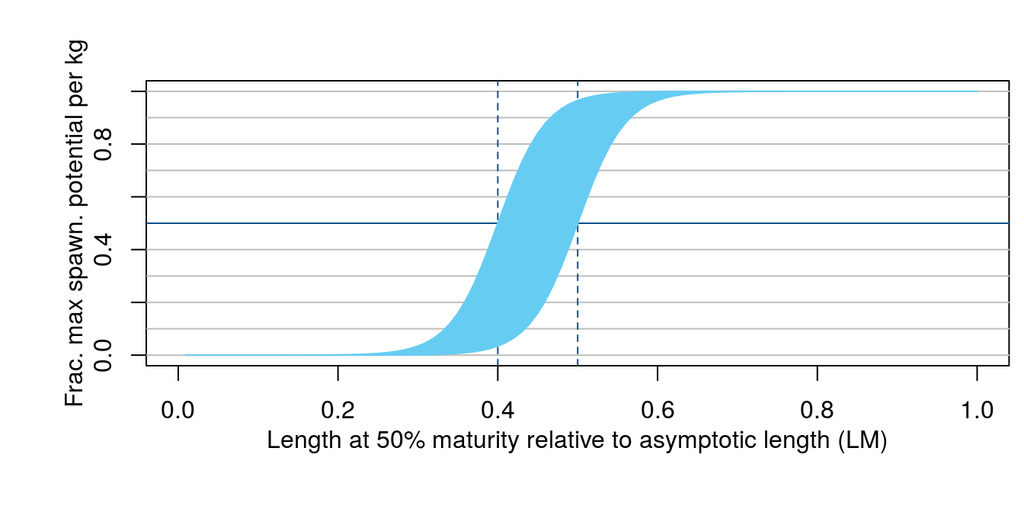

## 3.9 Selectivity of small fish

| Answered |
| --- |
| Very small (0.1 < S < 0.2) |
| Small (0.2 < S < 0.4) |
| Half asymptotic length (0.4 < S < 0.6) |
| Large (0.6 < S < 0.8) |
| Very large (0.8 < S < 0.9) |

[output not shown]

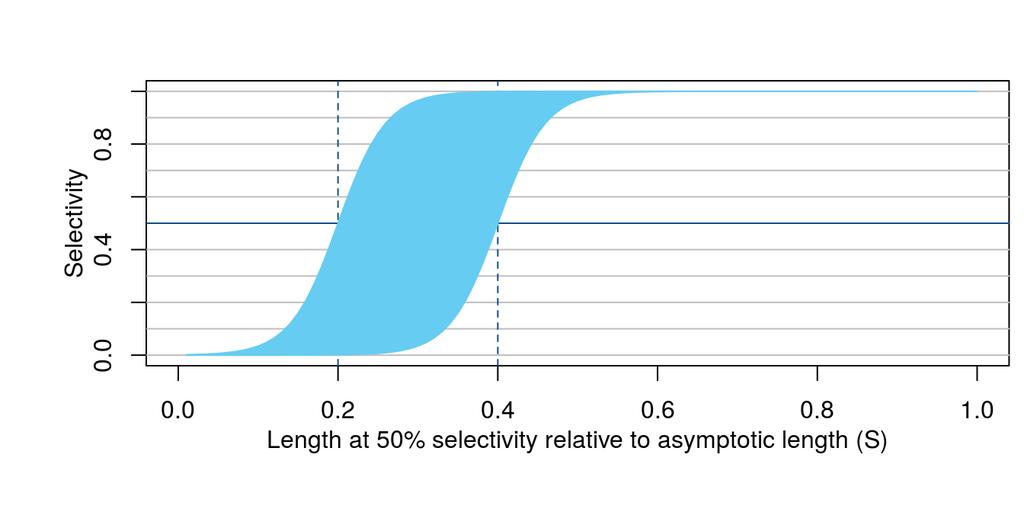

## 3.10 Selectivity of large fish

| Answered |
| --- |
| Asymptotic selectivity (SL = 1) |
| Declining selectivity with length (0.75 < SL < 1) |
| Dome-shaped selectivity (0.25 < SL < 0.75) |
| Strong dome-shaped selectivity (SL < 0.25) |

Justification

In the RPA, the total estimated discards from non-groundfish fisheries were less than 20 t annually for both the 5Zjm area and the adjacent 4X5Y stock area, from 2002 to 2006, based on extrapolating reports from at-sea observers. However, levels of observer coverage in non-groundfish fisheries were found to be generally low and intermittent. One of the measures recommended in the RPA for promoting recovery was to increase at-sea observer coverage in fisheries where the potential for catching and discarding of cod is high so that mortality from non-groundfish fisheries can be better estimated. In recent years, the target for observer coverage has been exceeded, with coverage ranging from 12-17% of trips. Average estimated cod bycatch in the whole of the LFA 41 fishing grounds for the period of 2014-2016 is 4,133 kg annually, down from 10,866 kg annually in the 2008-2010 period (SAR 2018/004) (http://www.dfo-mpo.gc.ca/fisheries-peches/ifmp-gmp/cod-morue/cod-morue-2019-eng.html)  
The fishery partial recruitment (PR) has domed substantially since 2010, especially when compared to the relatively flat pattern seen in the earlier time periods for ages 6 through 9 (Figure 30)

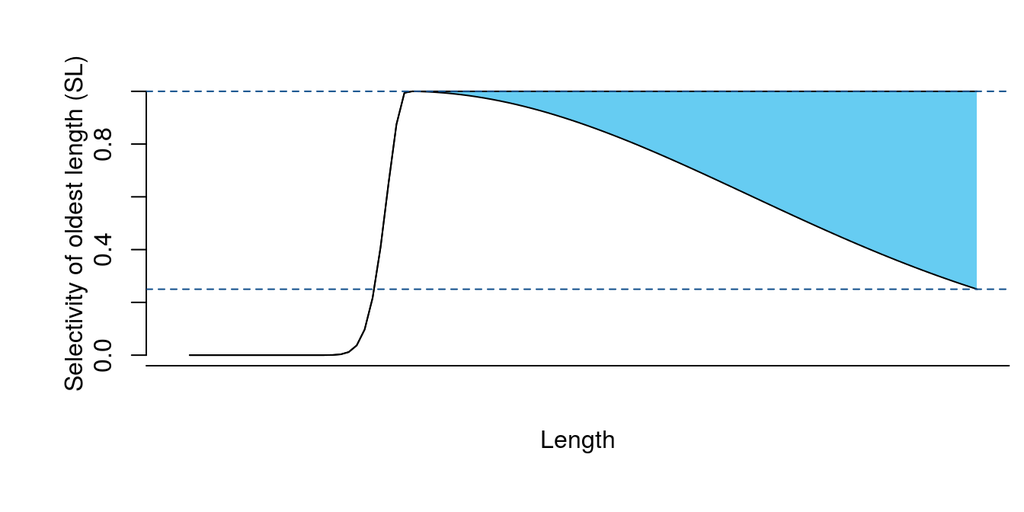

## 3.11 Discard rate

| Answered |
| --- |
| Low (DR < 1%) |
| Low - moderate (1% < DR < 10%) |
| Moderate (10% < DR < 30%) |
| Moderate - high (30% < DR < 50%) |
| High (50% < DR < 70%) |

Justification

In the RPA, the total estimated discards from non-groundfish fisheries were less than 20 t annually for both the 5Zjm area and the adjacent 4X5Y stock area, from 2002 to 2006, based on extrapolating reports from at-sea observers. However, levels of observer coverage in non-groundfish fisheries were found to be generally low and intermittent. One of the measures recommended in the RPA for promoting recovery was to increase at-sea observer coverage in fisheries where the potential for catching and discarding of cod is high so that mortality from non-groundfish fisheries can be better estimated. In recent years, the target for observer coverage has been exceeded, with coverage ranging from 12-17% of trips. Average estimated cod bycatch in the whole of the LFA 41 fishing grounds for the period of 2014-2016 is 4,133 kg annually, down from 10,866 kg annually in the 2008-2010 period (SAR 2018/004) (http://www.dfo-mpo.gc.ca/fisheries-peches/ifmp-gmp/cod-morue/cod-morue-2019-eng.html)  
From Table 1 (Andrushchenko et al 2018) average Catches (mt) for USA and Canasda is 10558 and 302 for discarding (Scallop, groundfish and USA fishery). So 302/10558= 0.0286039. Anod for 2017 around 0.04%

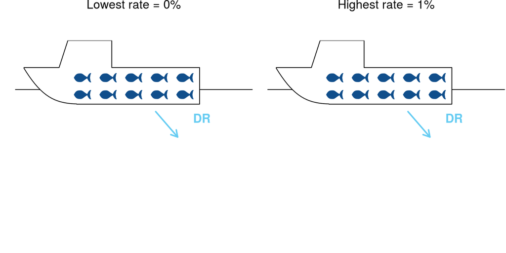

## 3.12 Post-release mortality rate

| Answered |
| --- |
| Low (PRM < 5%) |
| Low - moderate (5% < PRM < 25%) |
| Moderate (25% < PRM < 50%) |
| Moderate - high (50% < PRM < 75%) |
| High (75% < PRM < 95%) |
| Almost all die (95% < PRM < 100%) |

| Justification |
| --- |
| from Establishing Discard Mortality Rates for Atlantic Cod Stock AssessmentsUsing a Modified Delphi Technique workshop the Post-release mortality rate have a high uncertainty |

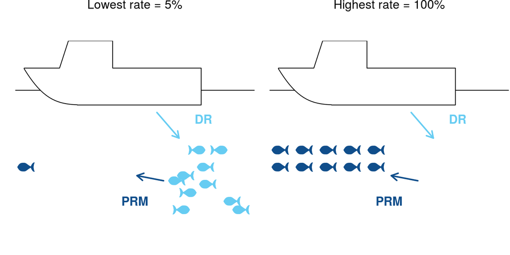

## 3.13 Recruitment variability

| Answered |
| --- |
| Very low (less than 10% inter-annual changes (IAC)) |
| Low (max IAC of between 20% and 60%) |
| Moderate (max IAC of between 60% and 120%) |
| High (max IAC of between 120% and 180%) |
| Very high (max IAC greater than 180%) |

| Justification |
| --- |
| 0.73. Goodwin et (2006) |

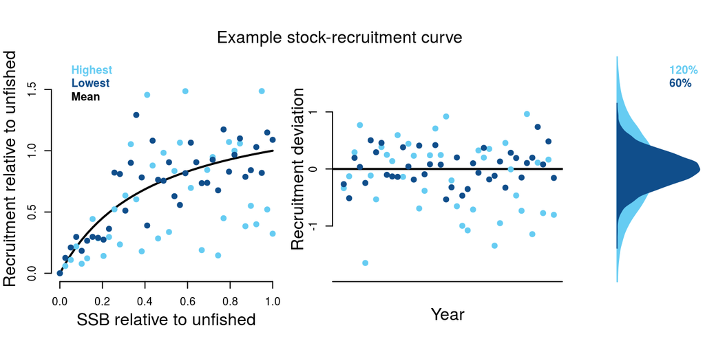

## 3.14 Size of an existing MPA

| Answered |
| --- |
| None |
| Small (A < 5%) |
| Small-moderate (5% < A < 10%) |
| Moderate (10% < A < 20%) |
| Large (20% < A < 30%) |
| Very large (30% < A < 40%) |
| Huge (40% < A < 50%) |

Justification

Closed areas: In addition to quota-based management, DFO regularly uses measures intended to reduce catch of juvenile fish and increase their chances of surviving to maturity and contributing to stock productivity, including both ad hoc and permanent small-fish closures. Seasonal spawning closures are also widely used, and a 7-week seasonal cod spawning closure of the offshore scallop fishery in February and March occurs annually (DFO 2017). There is also a regulated closure of the groundfish fishery on Georges Bank, which occurs annually from March 1 to May 31 to protect spawning aggregations of cod and haddock. Through licence conditions, this spawning closure has been extended to begin in early February. Originally, the closure date was selected using a protocol incorporating spawning condition from previous years with the goal of closing the fishery when 30% of the cod and haddock are in spawning condition. In 2010, a fixed date at the end of the 5th week of the year was adopted to close the fishery based on maturity data from previous years and consultation with the fishing industry (http://www.dfo-mpo.gc.ca/fisheries-peches/ifmp-gmp/cod-morue/cod-morue-2019-eng.html)

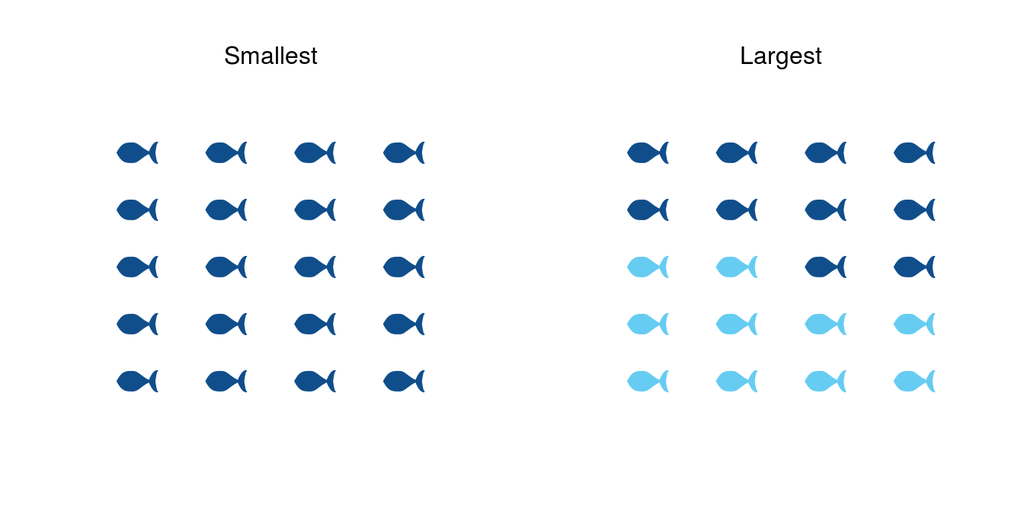

## 3.15 Spatial mixing (movement) in/out of existing MPA

| Answered |
| --- |
| Very low (P < 1%) |
| Low (1% < P < 5%) |
| Moderate (5% < P < 10%) |
| High (10% < P < 20%) |
| Fully mixed |

| Justification |
| --- |
| No info was found |

[figure not shown]

## 3.16 Size of a future potential MPA

| Answered |
| --- |
| None |
| Small (A < 5%) |
| Small-moderate (5% < A < 10%) |
| Moderate (10% < A < 20%) |
| Large (20% < A < 30%) |
| Very large (30% < A < 40%) |
| Huge (40% < A < 50%) |

| Justification |
| --- |
| only it is mentioned temporal closures (Winter fishery from Jan. 1 to Feb. 7, 2016.) but not in terms of size (see APPENDIX A in Andrushchenko et al 2018) |

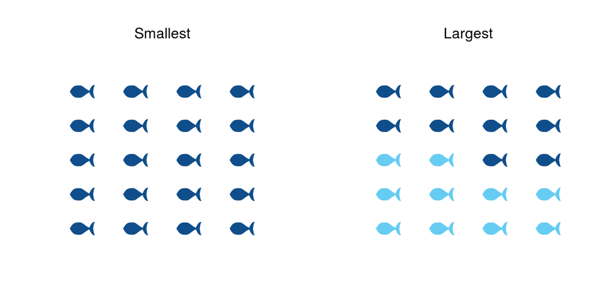

## 3.17 Spatial mixing (movement) in/out of future potential MPA

| Answered |
| --- |
| Very low (P < 1%) |
| Low (1% < P < 5%) |
| Moderate (5% < P < 10%) |
| High (10% < P < 20%) |
| Fully mixed |

| Justification |
| --- |
| No justification was provided |

[figure not shown]

## 3.18 Initial stock depletion

| Answered |
| --- |
| Very low (0.1 < D1 < 0.15) |
| Low (0.15 < D1 < 0.3) |
| Moderate (0.3 < D < 0.5) |
| High (0.5 < D1) |
| Asymptotic unfished levels (D1 = 1) |

| Justification |
| --- |
| no information was provided but model don’t start from unfished levels for sure |

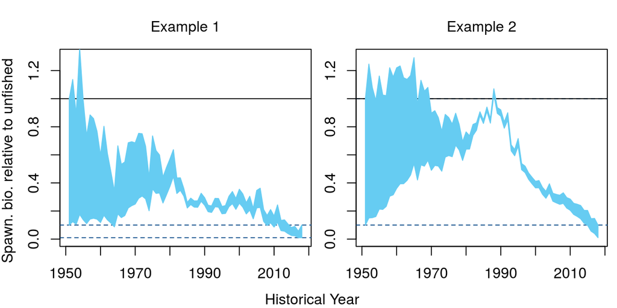

# 4 Management Characteristics

## 4.1 Types of fishery management that are possible

| Answered |
| --- |
| TAC (Total Allowable Catch): a catch limit |
| TAE (Total Allowable Effort): an effort limit |
| Size limit |
| Time-area closures (a marine reserve) |

Justification

1. Describe what, if any, current management measures are used to constrain catch/effort.  
The only mitigation measures identified under the 2011 RPA to increase survivorship of 5Z cod are reductions in directed fishing (to the level of FREF) and bycatch mortality. As natural mortality is estimated to be much higher for older fish than fishing mortality, there is no identified mechanism for reducing M. The primary control on fishery removals of 5Z cod is the TAC. All groundfish landings (directed and bycatch) are counted towards the quota, and no discarding of 5Z cod is permitted in groundfish fisheries. In addition to quota-based management, DFO regularly uses measures intended to reduce catch of juvenile fish and increase their chances of surviving to maturity and contributing to stock productivity, including both ad hoc and permanent small-fish closures. Seasonal spawning closures are also widely used, and a 7-week seasonal cod spawning closure of the offshore scallop fishery in February and March occurs annually (DFO 2017). There is also a regulated closure of the groundfish fishery on Georges Bank, which occurs annually from March 1 to May 31 to protect spawning aggregations of cod and haddock. Through licence conditions, this spawning closure has been extended to begin in early February. Originally, the closure date was selected using a protocol incorporating spawning condition from previous years with the goal of closing the fishery when 30% of the cod and haddock are in spawning condition. Small fish area closures may be enacted for specified fleet sectors when the number of undersized fish (species lengths vary) reaches or exceeds 15% of the catch. These closures can be enacted for both cod and haddock in Division 5Z with a minimum fish size for Atlantic cod of 43cm (http://www.dfo-mpo.gc.ca/fisheries-peches/ifmp-gmp/cod-morue/cod-morue-2019-eng.html).  
TAC (which may be introduced through fleet quota caps or trip limits), Small fish protocol, Gear modifications (e.g., mandatory use of a cod separator panel when fishing with mobile gear in 5Z), Size selectivity through gear restrictions (e.g., mesh and hook size constraints), and Bycatch limits when directing for other groundfish (http://www.dfo-mpo.gc.ca/fisheries-peches/ifmp-gmp/cod-morue/cod-morue-2019-eng.html)  
2. Describe historical management measures, if any.  
Canadian fishery management history of cod on eastern Georges Bank, 1978 to 2016 is give in APPENDIX A (Andrushchenko, I., and C.M. Legault, R. Martin, E.N. Brooks, & Y. Wang. 2018. Assessment of Eastern Georges Bank Atlantic Cod 2018. TRAC Res. Doc. 2018/01: 6p.)  
3. Describe main strengths and weaknesses of current monitoring and enforcement capacity.  
for At sea observer coverage see APPENDIX A (Andrushchenko et al 2018)  
4. Describe and reference any legal/policy requirements for management, monitoring and enforcement.  
see APPENDIX A (Andrushchenko et al 2018)

## 4.2 TAC offset: consistent overages/underages

| Answered |
| --- |
| Large underages (40% - 70% of recommended) |
| Underages (70% - 90% of recommended) |
| Slight underages (90% - 100% of recommended) |
| Taken exactly (95% - 105% of recommended) |
| Slight overages (100% - 110% of recommended) |
| Overages (110% - 150% of recommended) |
| Large overages (150% - 200% of recommended) |

[output not shown]

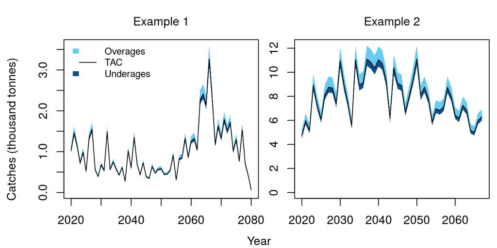

## 4.3 TAC implementation variability

| Answered |
| --- |
| Constant (V < 1%) |
| Not variable (1% < V < 5%) |
| Low variability (5% < V < 10%) |
| Variable (10% < V < 20%) |
| Highly variable (20% < V < 40%) |

| Justification |
| --- |
| from Table 3: Cod catches and biomass (thousands mt); Recruits (millions) for 5Z from 2009-2017 (TMGC 2018/01) (http://www.dfo-mpo.gc.ca/fisheries-peches/ifmp-gmp/cod-morue/cod-morue-2019-eng.html) |

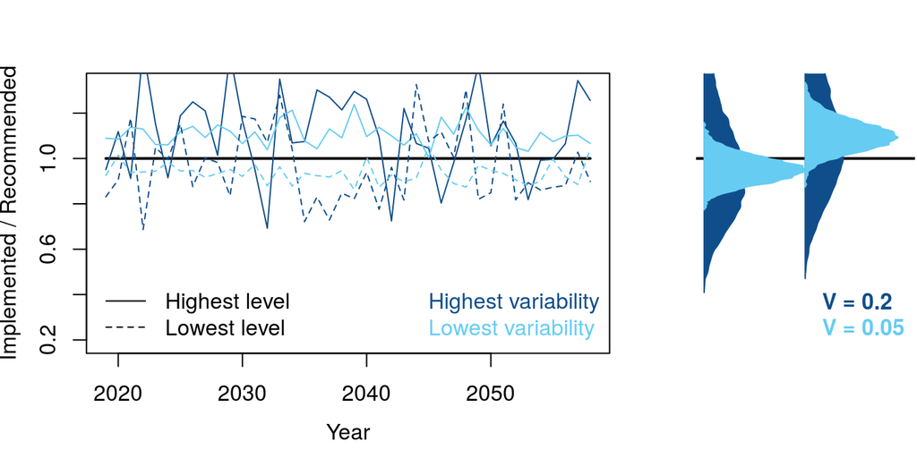

## 4.4 TAE offset: consistent overages/underages

| Answered |
| --- |
| Large underages (40% - 70% of recommended) |
| Underages (70% - 90% of recommended) |
| Slight underages (90% - 100% of recommended) |
| Taken exactly (95% - 105% of recommended) |
| Slight overages (100% - 110% of recommended) |
| Overages (110% - 150% of recommended) |
| Large overages (150% - 200% of recommended) |

| Justification |
| --- |
| No justification was provided |

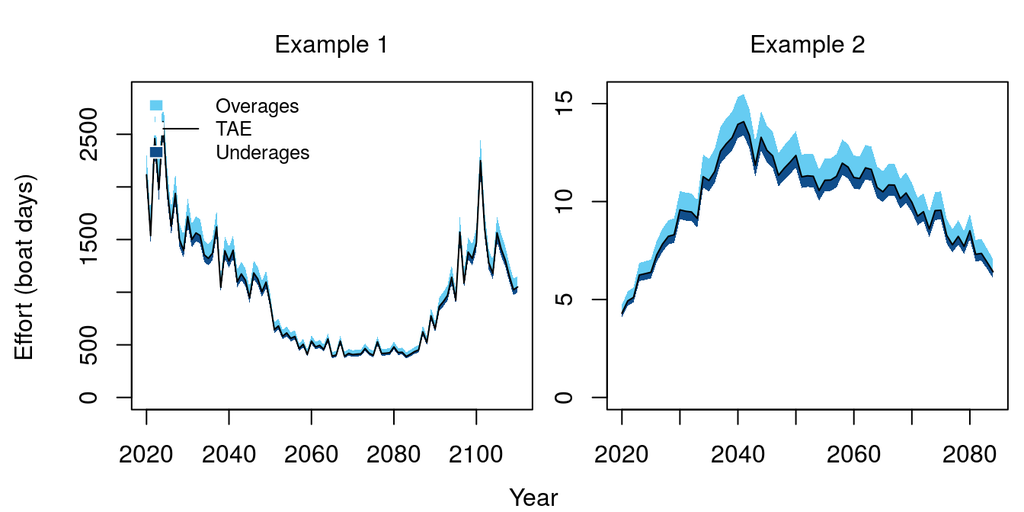

## 4.5 TAE implementation variability

| Answered |
| --- |
| Constant (V < 1%) |
| Not variable (1% < V < 5%) |
| Low variability (5% < V < 10%) |
| Variable (10% < V < 20%) |
| Highly variable (20% < V < 40%) |

| Justification |
| --- |
| No justification was provided |

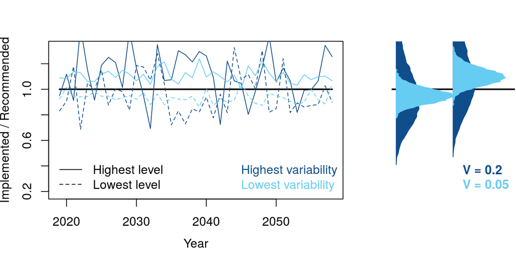

## 4.6 Size limit offset: consistent overages/underages

| Answered |
| --- |
| Much smaller (40% - 70% of recommended) |
| Smaller (70% - 90% of recommended) |
| Slightly smaller (90% - 100% of recommended) |
| Taken exactly (95% - 105% of recommended) |
| Slightly larger (100% - 110% of recommended) |
| Larger (110% - 150% of recommended) |
| Much larger (150% - 200% of recommended) |

| Justification |
| --- |

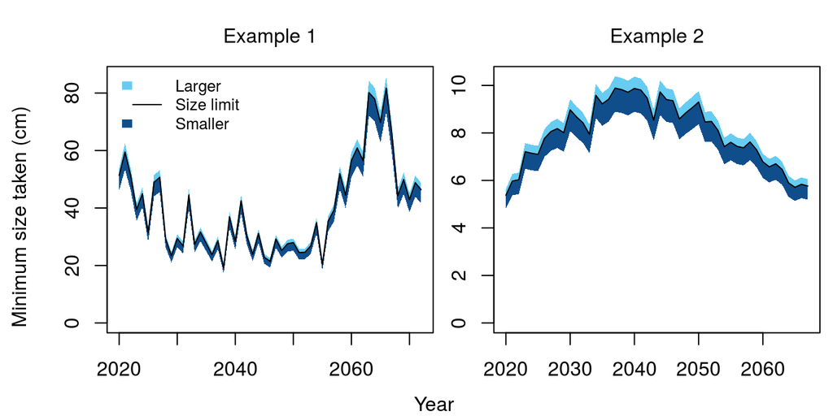

## 4.7 Size limit implementation variability

| Answered |
| --- |
| Constant (V < 1%) |
| Not variable (1% < V < 5%) |
| Low variability (5% < V < 10%) |
| Variable (10% < V < 20%) |
| Highly variable (20% < V < 40%) |

| Justification |
| --- |
| No justification was provided |

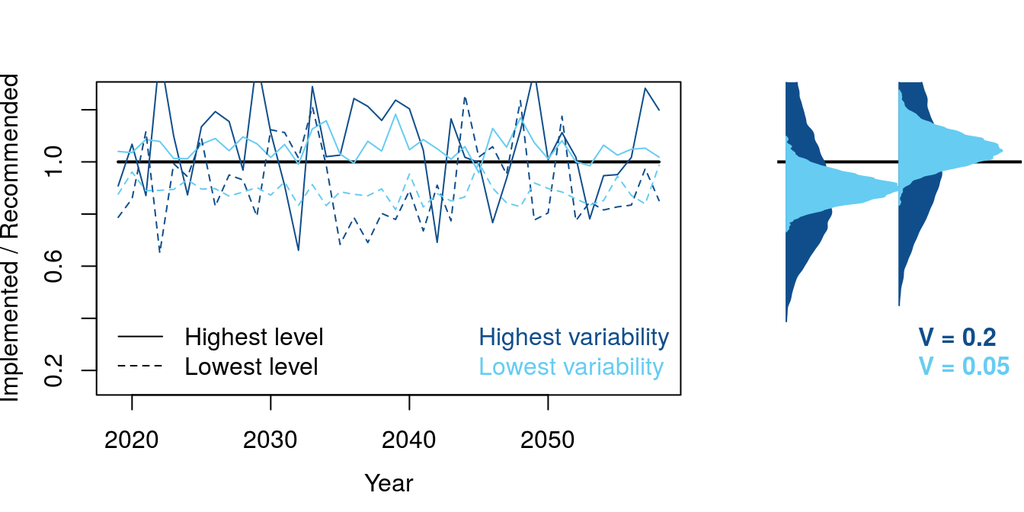

# 5 Data Characteristics

## 5.1 Available data types

| Answered |
| --- |
| Historical annual catches (from unfished) |
| Recent annual catches (at least 5 recent years) |
| Historical relative abundance index (from unfished) |
| Recent relative abundance index (at least 5 recent years) |
| Fishing effort |
| Size composition (length samples) |
| Age composition (age samples) |
| Growth (growth parameters) |
| Absolute biomass survey |

Justification

1. Provide the time series (specify years, if possible) that exist for catch, effort, and CPUE/abundance indices.  
Table 1. Catches (mt) of cod from eastern Georges Bank, 1978 to 2017 (Andrushchenko et al 2018)  
Table 3. Annual catch at age numbers (thousands) for eastern Georges Bank cod for 1978-2017 (Andrushchenko et al 2018)  
Table 6. Indices of swept area abundance (thousands) for eastern Georges Bank cod from the DFO survey, 1986-2018 (Andrushchenko et al 2018)  
Table 7. Indices of swept area abundance (thousands) for eastern Georges Bank cod from the NMFS spring survey, 1970-2018 (Andrushchenko et al 2018)  
2. Describe how these data collected (e.g., log books, dealer reporting, observers).  
Monitoring tools in use vary by fleet and include hails, dockside monitoring of landings, at-sea observer coverage, logbooks, and vessel monitoring systems. Please refer to Section 5.1 of the 4VWX5 Groundfish IFMP for additional details (http://www.dfo-mpo.gc.ca/fisheries-peches/ifmp-gmp/cod-morue/cod-morue-2019-eng.html). For groundfish fisheries, unreported (and illegal) discards would be the main source of unaccounted fishing mortality, although observer coverage rates in the groundfish fishery on Georges Bank have been high (25-100%) for many years.  
3. Describe what types of sampling programs and methodologies exist for data collection, including the time-series of available sampling data and quality.  
The Georges Bank fishery is separated into US and Canadian management regimes. When fishing on Georges Bank, all Canadian vessels are required to hail out prior to departing on a fishing trip, to hail in upon return, and to carry Vessel Monitoring Systems (VMS) on board. All Canadian Georges Bank landings are monitored at the point of offloading by third-party dockside monitors. These monitors verify the weight and the species of fish offloaded. Detailed catch and effort information for every trip must be recorded in logbooks and submitted to DFO (via a dockside monitoring company). Estimates of discarded Atlantic cod within the haddock fishery on Georges Bank are calculated by comparing the catch on unobserved trips to trips with at-sea observers. The Eastern Georges Bank haddock fishery has an observer coverage rate of 25-100%. Tables 4 and 5 show the actual observer coverage for the 5Zjm haddock mobile gear and longline fisheries from 2015 to 2018 (http://www.dfo-mpo.gc.ca/fisheries-peches/ifmp-gmp/cod-morue/cod-morue-2019-eng.html)  
4. Describe all sources of uncertainty in the status, biology, life history and data sources of the fishery. Include links to documentation, reports.  
In 2011, the RPA identified that an increase in seal populations may contribute to the high natural mortality for 5Z Atlantic cod, but stated that the degree to which seals contribute to natural mortality has yet to be quantified. Therefore, it is not known to what extent management of the seal population would assist in the rebuilding of the stock. In addition to scientific uncertainty, significant logistical and political constraints may limit the feasibility of any management measures to reduce the seal population (http://www.dfo-mpo.gc.ca/fisheries-peches/ifmp-gmp/cod-morue/cod-morue-2019-eng.html)  
Performance of the VPA and ASAP for Eastern Georges Bank cod was poor and seemed to be getting worse with time with regard to model diagnostics. Some of the diagnostic issues were poor fits to the survey data and significant retrospective patterns in biomass, fishing mortality, and recruitment, indicating an undiagnosed misspecification in the model. The VPA and ASAP modeling approaches are becoming increasingly unreliable for providing management advice (Andrushchenko et al 2018, p14)

## 5.2 Catch reporting bias

| Answered |
| --- |
| Strong under-reporting (30% - 50%) |
| Under-reporting (10% - 30%) |
| Slight under-reporting (less than 10%) |
| Reported accurately (+/- 5%) |
| Slight over-reporting (less than 10%) |

| Justification |
| --- |
| No information was provided but discarding is monitored and At sea observer coverage has improved for the recent years (see APPENDIX A in Andrushchenko et al 2018) |

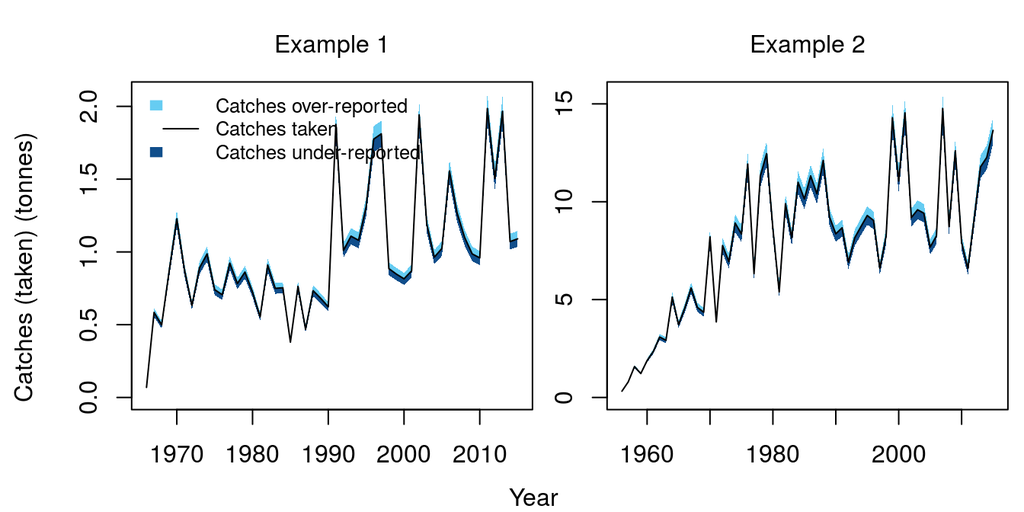

## 5.3 Hyperstability in indices

| Answered |
| --- |
| Strong hyperdepletion (2 < Beta < 3) |
| Hyperdepletion (1.25 < Beta < 2) |
| Proportional (0.8 < Beta < 1.25) |
| Hyperstability (0.5 < Beta < 0.8) |
| Strong hyperstability (0.33 < Beta < 0.5) |

| Justification |
| --- |
| No information was provided |

[figure not shown]

## 5.4 Available data types

| Answered |
| --- |
| Perfect |
| Good (accurate and precise) |
| Data moderate (some what inaccurate and imprecise) |
| Data poor (inaccurate and imprecise) |

Justification

Performance of the VPA and ASAP for Eastern Georges Bank cod was poor and seemed to be getting worse with time with regard to model diagnostics. Some of the diagnostic issues were poor fits to the survey data and significant retrospective patterns in biomass, fishing mortality, and recruitment, indicating an undiagnosed misspecification in the model. The VPA and ASAP modeling approaches are becoming increasingly unreliable for providing management advice (Andrushchenko et al 2018)

# 6 Version Notes

The package is subject to ongoing testing. If you find a bug or a problem please send a report to t.carruthers@oceans.ubc.ca so that it can be fixed!

shiny-2019-07-31-19:44:12

Open Source, GPL-2 2019